# Correlated Systems of Statistical Equations with Multiple Variable Types

Allison C Fialkowski

2018-06-21

The following examples demonstrate the use of the `corrsys` and `corrsys2` functions within the **SimRepeat** package. These functions generate correlated systems of `M` equations representing a **system of repeated measures** at `M` time points. The equations may contain 1) ordinal ($r \geq 2$ categories), continuous (normal, non-normal, and mixture distributions), and/or count (regular and zero-inflated, Poisson and Negative Binomial) independent variables $X$; 2) continuous error terms $E$; 3) a discrete time variable $Time$; and 4) random effects $U$. The random effects may be a random intercept, a random slope for time, or a random slope for any of the $X$ variables. The **important assumptions** are:

1. There are at least 2 equations with at least 1 independent variable total.
2. The independent variables, random effect terms, and error terms are uncorrelated.
3. Each equation has an error term.
4. All error terms have continuous non-mixture distributions or all have continuous mixture distributions.
5. All random effects are continuous.
6. Growth is linear with respect to time.

The outcomes $Y$ are generated using a hierarchical linear models (HLM) approach. See The Hierarchical Linear Models Approach for a System of Correlated Equations with Multiple Variable Types vignette for a description of the HLM model. The independent variables, error terms, and random effects are generated from multivariate normal variables with intermediate correlations calculated using either `SimCorrMix::intercorr` and **correlation method 1** for `corrsys` or `SimCorrMix::intercorr2` and **correlation method 2** for `corrsys2`. See the **SimCorrMix** package for a description of the correlation methods and the techniques used to generate each variable type.

The `corrsys` and `corrsys2` functions contain no parameter checks in order to decrease simulation time. That should be done first using `checkpar`. Summaries of the system can be obtained using `summary_sys`. More information regarding function inputs can be found by consulting the function documentation. Some code has been adapted from the **SimMultiCorrData** (Fialkowski 2017) and **SimCorrMix** (Fialkowski 2018) packages.

**Example 1** demonstrates the `corrsys` function to generate a system of 3 equations for 5 independent variables with no random effects. **Example 2** uses the `corrsys2` function to demonstrate how to handle missing variables by removing the independent variables from $Y_2$ in Example 1. **Example 3** generates a system of system of 4 equations with random effects.

#### Notes on fitting linear mixed models in R:

There are two main options for fitting mixed effects models in R. The **nlme** package (Pinheiro et al. 2017) permits linear and nonlinear mixed models. Linear models are fit using **lme** (see Laird and Ware (1982)); nonlinear models are fit using **nlme** (see Lindstrom and Bates (1990)). Both allow nested random effects and the within-group errors can be correlated and/or have unequal variances. The `correlation` argument permits several different correlation structures, including AR(1) and CS (see that package’s documentation). Setting `weights = varIdent(form =` $\sim$ `1 | time)` achieves unequal variances across time.

The **lme4** package (Bates, Mächler, et al. 2015) permits linear (`lmer`), generalized linear (`glmer`), and nonlinear (`nlmer`) mixed models. Since there are no specific function arguments, implementing different error term correlation structures is more difficult than in **nlme**. Certain error structures can be achieved through manipulation of the data and models (see Bates, Mächler, et al. (2015)). However, **lme4** implements crossed random effects more efficiently and contains facilities for likelihood profiling and parametric bootstrapping. The **lmerTest** package (Kuznetsova, Brockhoff, and Christensen 2017) provides $p$-values for beta coefficients.

## Example 1: System of 3 equations for 5 independent variables

### Description of Variables

1. **Ordinal variable:** $X_{ord(1)}$ has 3 categories (i.e., drug treatment) and is the same in each equation
2. **Continuous variables:**
1. $X_{cont(1)}$ is a time-varying covariate (subject-level term) with a Rice distribution with increasing variance and an AR(1, p = 0.5) correlation structure
1. $X_{cont(11)}$ has a Rice(1, 0.5) distribution which requires a sixth cumulant correction of 0.08
2. $X_{cont(21)}$ has a Rice(2, 2) distribution which requires a sixth cumulant correction of 0.12
3. $X_{cont(31)}$ has a Rice(4, 8) distribution which requires a sixth cumulant correction of 0.36
2. $X_{mix(1)}$ is a mixture of Normal(-5, 2) and Normal(3, 1) with mixing parameters 0.3 and 0.7; it is a time-varying covariate (subject-level term) and the components have an AR(1, p = 0.4) correlation structure across Y
3. **Poisson variable:** $X_{pois(1)}$ is a zero-inflated Poisson variable with $\lambda = 15$, the probability of a structural zero set at $0.10$, and is the same in each equation
4. **Negative Binomial variable:** $X_{nb(1)}$ is a regular NB time-varying covariate (subject-level term) with an AR(1, p = 0.3) correlation structure and increasing mean and variance
1. $X_{nb(11)}$ has a size of 10 and mean of 3
2. $X_{nb(21)}$ has a size of 10 and mean of 4
3. $X_{nb(31)}$ has a size of 10 and mean of 5
5. **Error terms** have Skewnormal distributions which become more skewed over time with an AR(1, p = 0.4) correlation structure:
1. $E_1$ has a Skewnormal(0, 1, 1) distribution which requires a sixth cumulant correction of 0.06
2. $E_2$ has a Skewnormal(0, 1, 5) distribution
3. $E_3$ has a Skewnormal(0, 1, 25) distribution which requires a sixth cumulant correction of 0.15

### Description of Variables

There is an interaction between $X_{ord(1)}$ and $X_{pois(1)}$ for each $Y$. Since they are both group-level covariates, the interaction is also a group-level covariate that will interact with the subject-level covariates $X_{cont(1)}$, $X_{mix(1)}$, and $X_{nb(1)}$. However, only $X_{ord(1)}$ and $X_{pois(1)}$ interact with time in this example (normally their interaction would also interact with time). The ordering in the equations below reflects the ordering in the simulation process.

$$\begin{equation}
\begin{split}
Y_1 &= \beta_0 + \beta_1 * X_{ord(1)} + \beta_2 * X_{cont(11)} + \beta_3 * X_{mix(11)} + \beta_4 * X_{pois(1)} + \beta_5 * X_{nb(11)} + \beta_{int} * X_{ord(1)} * X_{pois(1)} \\
&+ \beta_{subj1} * X_{ord(1)} * X_{cont(11)} + \beta_{subj2} * X_{pois(1)} * X_{cont(11)} + \beta_{subj3} * X_{ord(1)} * X_{pois(1)} * X_{cont(11)} \\
&+ \beta_{subj4} * X_{ord(1)} * X_{mix(11)} + \beta_{subj5} * X_{pois(1)} * X_{mix(11)} + \beta_{subj6} * X_{ord(1)} * X_{pois(1)} * X_{mix(11)} \\
&+ \beta_{subj7} * X_{ord(1)} * X_{nb(11)} + \beta_{subj8} * X_{pois(1)} * X_{nb(11)} + \beta_{subj9} * X_{ord(1)} * X_{pois(1)} * X_{nb(11)} \\
&+ \beta_{tint1} * X_{ord(1)} * Time_1 + \beta_{tint2} * X_{pois(1)} * Time_1 + \beta_{t} * Time_1 + E_1
\end{split}
\tag{1}
\end{equation}$$
$$\begin{equation}
\begin{split}
Y_2 &= \beta_0 + \beta_1 * X_{ord(1)} + \beta_2 * X_{cont(21)} + \beta_3 * X_{mix(21)} + \beta_4 * X_{pois(1)} + \beta_5 * X_{nb(21)} + \beta_{int} * X_{ord(1)} * X_{pois(1)} \\
&+ \beta_{subj1} * X_{ord(1)} * X_{cont(21)} + \beta_{subj2} * X_{pois(1)} * X_{cont(21)} + \beta_{subj3} * X_{ord(1)} * X_{pois(1)} * X_{cont(21)} \\
&+ \beta_{subj4} * X_{ord(1)} * X_{mix(21)} + \beta_{subj5} * X_{pois(1)} * X_{mix(21)} + \beta_{subj6} * X_{ord(1)} * X_{pois(1)} * X_{mix(21)} \\
&+ \beta_{subj7} * X_{ord(1)} * X_{nb(21)} + \beta_{subj8} * X_{pois(1)} * X_{nb(21)} + \beta_{subj9} * X_{ord(1)} * X_{pois(1)} * X_{nb(21)} \\
&+ \beta_{tint1} * X_{ord(1)} * Time_2 + \beta_{tint2} * X_{pois(1)} * Time_2 + \beta_{t} * Time_2 + E_2
\end{split}
\tag{2}
\end{equation}$$
$$\begin{equation}
\begin{split}
Y_3 &= \beta_0 + \beta_1 * X_{ord(1)} + \beta_2 * X_{cont(31)} + \beta_3 * X_{mix(31)} + \beta_4 * X_{pois(1)} + \beta_5 * X_{nb(31)} + \beta_{int} * X_{ord(1)} * X_{pois(1)} \\
&+ \beta_{subj1} * X_{ord(1)} * X_{cont(31)} + \beta_{subj2} * X_{pois(1)} * X_{cont(31)} + \beta_{subj3} * X_{ord(1)} * X_{pois(1)} * X_{cont(31)} \\
&+ \beta_{subj4} * X_{ord(1)} * X_{mix(31)} + \beta_{subj5} * X_{pois(1)} * X_{mix(31)} + \beta_{subj6} * X_{ord(1)} * X_{pois(1)} * X_{mix(31)} \\
&+ \beta_{subj7} * X_{ord(1)} * X_{nb(31)} + \beta_{subj8} * X_{pois(1)} * X_{nb(31)} + \beta_{subj9} * X_{ord(1)} * X_{pois(1)} * X_{nb(31)} \\
&+ \beta_{tint1} * X_{ord(1)} * Time_3 + \beta_{tint2} * X_{pois(1)} * Time_3 + \beta_{t} * Time_3 + E_3
\end{split}
\tag{3}
\end{equation}$$

```r
library("SimRepeat")
library("printr")
library("nlme")
library("reshape2")
options(scipen = 999)
```

### Step 1: Set up parameter inputs

This is the most time-consuming part of the simulation process. It is important to read the function documentation carefully to understand the formats for each parameter input. Incorrect formatting will lead to errors. Most of these can be prevented by using the `checkpar` function in **Step 2**.

```r
seed <- 137
n <- 10000
M <- 3

# Ordinal variable
marginal <- lapply(seq_len(M), function(x) list(c(1/3, 2/3)))
support <- lapply(seq_len(M), function(x) list(c(0, 1, 2)))

# Non-mixture continuous variables
method <- "Polynomial"
Stcum1 <- calc_theory("Rice", c(1, 0.5))
Stcum2 <- calc_theory("Rice", c(2, 2))
Stcum3 <- calc_theory("Rice", c(4, 8))

# Error terms
error_type <- "non_mix"
Error1 <- calc_theory("Skewnormal", c(0, 1, 1))
Error2 <- calc_theory("Skewnormal", c(0, 1, 5))
Error3 <- calc_theory("Skewnormal", c(0, 1, 25))
corr.e <- matrix(c(1, 0.4, 0.4^2, 0.4, 1, 0.4, 0.4^2, 0.4, 1), M, M,
  byrow = TRUE)

skews <- list(c(Stcum1[3], Error1[3]), c(Stcum2[3], Error2[3]),
  c(Stcum3[3], Error3[3]))
skurts <- list(c(Stcum1[4], Error1[4]), c(Stcum2[4], Error2[4]),
  c(Stcum3[4], Error3[4]))
fifths <- list(c(Stcum1[5], Error1[5]), c(Stcum2[5], Error2[5]),
  c(Stcum3[5], Error3[5]))
sixths <- list(c(Stcum1[6], Error1[6]), c(Stcum2[6], Error2[6]),
  c(Stcum3[6], Error3[6]))
Six <- list(list(0.08, 0.06), list(0.12, NULL), list(0.36, 0.15))

# Mixture continuous variable
mix_pis <- lapply(seq_len(M), function(x) list(c(0.3, 0.7)))
mix_mus <- lapply(seq_len(M), function(x) list(c(-5, 3)))
mix_sigmas <- lapply(seq_len(M), function(x) list(c(2, 1)))
mix_skews <- mix_skurts <- mix_fifths <- mix_sixths <-
  lapply(seq_len(M), function(x) list(c(0, 0)))
mix_Six <- list()
Nstcum <- calc_mixmoments(mix_pis[[1]][[1]], mix_mus[[1]][[1]],
  mix_sigmas[[1]][[1]], mix_skews[[1]][[1]], mix_skurts[[1]][[1]],
  mix_fifths[[1]][[1]], mix_sixths[[1]][[1]])

means <- list(c(Stcum1[1], Nstcum[1], 0),
  c(Stcum2[1], Nstcum[1], 0),
  c(Stcum3[1], Nstcum[1], 0))
vars <- list(c(Stcum1[2]^2, Nstcum[2]^2, Error1[2]^2),
  c(Stcum2[2]^2, Nstcum[2]^2, Error2[2]^2),
  c(Stcum3[2]^2, Nstcum[2]^2, Error3[2]^2))

# Poisson variable
lam <- list(15, 15, 15)
p_zip <- 0.10

# Negative Binomial variables
size <- list(10, 10, 10)
mu <- list(3, 4, 5)
prob <- list()
p_zinb <- 0

# X_ord(1) and X_pois(1) are the same across Y
same.var <- c(1, 5)

# set up X correlation matrix
corr.x <- list()
corr.x[[1]] <- list(matrix(0.4, 6, 6), matrix(0.35, 6, 6), matrix(0.25, 6, 6))
diag(corr.x[[1]][[1]]) <- 1
# set correlations between components of X_mix(11) to 0
corr.x[[1]][[1]][3:4, 3:4] <- diag(2)
# set correlations between time-varying covariates of Y1 and Y2
corr.x[[1]][[2]][2, 2] <- 0.5
corr.x[[1]][[2]][3:4, 3:4] <- matrix(0.4, 2, 2)
corr.x[[1]][[2]][6, 6] <- 0.3
# set correlations between time-varying covariates of Y1 and Y3
corr.x[[1]][[3]][2, 2] <- 0.5^2
corr.x[[1]][[3]][3:4, 3:4] <- matrix(0.4^2, 2, 2)
corr.x[[1]][[3]][6, 6] <- 0.3^2
# set correlations for the same variables equal across outcomes
corr.x[[1]][[2]][, same.var] <- corr.x[[1]][[3]][, same.var] <-
  corr.x[[1]][[1]][, same.var]

corr.x[[2]] <- list(t(corr.x[[1]][[2]]), matrix(0.35, 6, 6),
  matrix(0.25, 6, 6))
diag(corr.x[[2]][[2]]) <- 1
# set correlations between components of X_mix(21) to 0
corr.x[[2]][[2]][3:4, 3:4] <- diag(2)
# set correlations between time-varying covariates of Y2 and Y3
corr.x[[2]][[3]][2, 2] <- 0.5
corr.x[[2]][[3]][3:4, 3:4] <- matrix(0.4, 2, 2)
corr.x[[2]][[3]][6, 6] <- 0.3
# set correlations for the same variables equal across outcomes
corr.x[[2]][[2]][same.var, ] <- corr.x[[1]][[2]][same.var, ]
corr.x[[2]][[2]][, same.var] <- corr.x[[2]][[3]][, same.var] <-
  t(corr.x[[1]][[2]][same.var, ])
corr.x[[2]][[3]][same.var, ] <- corr.x[[1]][[3]][same.var, ]

corr.x[[3]] <- list(t(corr.x[[1]][[3]]), t(corr.x[[2]][[3]]),
  matrix(0.3, 6, 6))
diag(corr.x[[3]][[3]]) <- 1
# set correlations between components of X_mix(31) to 0
corr.x[[3]][[3]][3:4, 3:4] <- diag(2)
# set correlations for the same variables equal across outcomes
corr.x[[3]][[3]][same.var, ] <- corr.x[[1]][[3]][same.var, ]
corr.x[[3]][[3]][, same.var] <- t(corr.x[[3]][[3]][same.var, ])

Time <- 1:M
betas.0 <- 0
betas.t <- 1
# use a list of length 1 so that betas are the same across Y
betas <- list(seq(0.5, 1.5, 0.25))
# interaction between ordinal and Poisson variable, becomes
# another group-level variable
int.var <- matrix(c(1, 1, 4, 2, 1, 4, 3, 1, 4), 3, 3, byrow = TRUE)
betas.int <- list(0.5)
# continuous non-mixture, continuous mixture, and NB variables are
# subject-level variables
subj.var <- matrix(c(1, 2, 1, 3, 1, 5, 2, 2, 2, 3, 2, 5, 3, 2, 3, 3, 3, 5),
  nrow = 9, ncol = 2, byrow = TRUE)
# there are 3 subject-level variables and 3 group-level variables forming
# 9 group-subject interactions
betas.subj <- list(seq(0.5, 0.5 + (9 - 1) * 0.1, 0.1))
# only ordinal and Poisson variable interact with time (excluding the
# ordinal-Poisson interaction variable)
tint.var <- matrix(c(1, 1, 1, 4, 2, 1, 2, 4, 3, 1, 3, 4), 6, 2, byrow = TRUE)
betas.tint <- list(c(0.25, 0.5))
```

### Step 2: Check parameter inputs

```r
checkpar(M, method, error_type, means, vars, skews, skurts, fifths, sixths,
  Six, mix_pis, mix_mus, mix_sigmas, mix_skews, mix_skurts, mix_fifths,
  mix_sixths, mix_Six, marginal, support, lam, p_zip, pois_eps = list(),
  size, prob, mu, p_zinb, nb_eps = list(), corr.x, corr.yx = list(), corr.e,
  same.var, subj.var, int.var, tint.var, betas.0, betas, betas.subj, betas.int,
  betas.t, betas.tint, quiet = TRUE)
```

```
## [1] TRUE
```

### Step 3: Generate system

Note that `use.nearPD = FALSE` and `adjgrad = FALSE` so that negative eigen-values will be replaced with `eigmin` (default $0$) instead of using the nearest positive-definite matrix (found with Bates and Maechler (2017)’s `Matrix::nearPD` function by Higham (2002)’s algorithm) or the adjusted gradient updating method via `adj_grad` (Yin and Zhang 2013; Zhang and Yin Year not provided; Maree 2012).

```r
Sys1 <- corrsys(n, M, Time, method, error_type, means, vars,
  skews, skurts, fifths, sixths, Six, mix_pis, mix_mus, mix_sigmas, mix_skews,
  mix_skurts, mix_fifths, mix_sixths, mix_Six, marginal, support, lam, p_zip,
  size, prob, mu, p_zinb, corr.x, corr.e, same.var, subj.var, int.var,
  tint.var, betas.0, betas, betas.subj, betas.int, betas.t, betas.tint,
  seed = seed, use.nearPD = FALSE, quiet = TRUE)
```

```
## Total Simulation time: 0.43 minutes
```

```r
knitr::kable(Sys1$constants[[1]], booktabs = TRUE,
  caption = "PMT constants for Y_1")
```

Table 1: PMT constants for Y_1

| c0 | c1 | c2 | c3 | c4 | c5 |
| --- | --- | --- | --- | --- | --- |
| -0.1150419 | 1.0356110 | 0.1172383 | -0.0189393 | -0.0007322 | 0.0005196 |
| 0.0000000 | 1.0000000 | 0.0000000 | 0.0000000 | 0.0000000 | 0.0000000 |
| 0.0000000 | 1.0000000 | 0.0000000 | 0.0000000 | 0.0000000 | 0.0000000 |
| -0.0234264 | 0.9949525 | 0.0242231 | 0.0014391 | -0.0002656 | 0.0000140 |

```r
Sys1$valid.pdf
```

```
## [[1]]
## [1] "TRUE" "TRUE" "TRUE" "TRUE"
##
## [[2]]
## [1] "TRUE" "TRUE" "TRUE" "TRUE"
##
## [[3]]
## [1] "TRUE" "TRUE" "TRUE" "TRUE"
```

### Step 4: Describe results

```r
Sum1 <- summary_sys(Sys1$Y, Sys1$E, E_mix = NULL, Sys1$X, Sys1$X_all, M,
  method, means, vars, skews, skurts, fifths, sixths, mix_pis, mix_mus,
  mix_sigmas, mix_skews, mix_skurts, mix_fifths, mix_sixths, marginal,
  support, lam, p_zip, size, prob, mu, p_zinb, corr.x, corr.e)
names(Sum1)
```

```
##  [1] "cont_sum_y"   "rho.y"        "cont_sum_e"   "target_sum_e"
##  [5] "rho.e"        "rho.ye"       "ord_sum_x"    "cont_sum_x"
##  [9] "target_sum_x" "sum_xall"     "mix_sum_x"    "target_mix_x"
## [13] "pois_sum_x"   "nb_sum_x"     "rho.x"        "rho.xall"
## [17] "rho.yx"       "rho.yxall"    "maxerr"
```

```r
knitr::kable(Sum1$cont_sum_y, digits = 3, booktabs = TRUE,
  caption = "Simulated Distributions of Outcomes")
```

Table 2: Simulated Distributions of Outcomes

|  | Outcome | N | Mean | SD | Median | Min | Max | Skew | Skurtosis | Fifth | Sixth |
| --- | --- | --- | --- | --- | --- | --- | --- | --- | --- | --- | --- |
| Y1 | 1 | 10000 | 233.654 | 261.038 | 156.228 | -310.398 | 1828.218 | 1.470 | 2.717 | 5.195 | 7.541 |
| Y2 | 2 | 10000 | 318.684 | 316.982 | 226.806 | -356.880 | 2589.484 | 1.498 | 2.968 | 6.973 | 17.490 |
| Y3 | 3 | 10000 | 484.949 | 419.921 | 368.659 | -183.236 | 2834.555 | 1.210 | 1.466 | 0.733 | -5.194 |

```r
knitr::kable(Sum1$target_sum_e, digits = 3, booktabs = TRUE,
  caption = "Target Distributions of Error Terms")
```

Table 3: Target Distributions of Error Terms

|  | Outcome | Mean | SD | Skew | Skurtosis | Fifth | Sixth |
| --- | --- | --- | --- | --- | --- | --- | --- |
| E1 | 1 | 0 | 0.826 | 0.137 | 0.062 | -0.002 | -0.060 |
| E2 | 2 | 0 | 0.623 | 0.851 | 0.705 | -0.043 | -2.326 |
| E3 | 3 | 0 | 0.604 | 0.989 | 0.862 | -0.055 | -3.140 |

```r
knitr::kable(Sum1$cont_sum_e, digits = 3, booktabs = TRUE,
  caption = "Simulated Distributions of Error Terms")
```

Table 4: Simulated Distributions of Error Terms

|  | Outcome | N | Mean | SD | Median | Min | Max | Skew | Skurtosis | Fifth | Sixth |
| --- | --- | --- | --- | --- | --- | --- | --- | --- | --- | --- | --- |
| E1 | 1 | 10000 | 0 | 0.825 | -0.023 | -3.214 | 2.909 | 0.100 | 0.012 | -0.217 | -0.238 |
| E2 | 2 | 10000 | 0 | 0.628 | -0.106 | -1.720 | 3.311 | 0.893 | 0.747 | -0.223 | -3.786 |
| E3 | 3 | 10000 | 0 | 0.605 | -0.124 | -1.003 | 4.680 | 1.011 | 1.095 | 1.942 | 11.806 |

```r
knitr::kable(Sum1$target_sum_x, digits = 3, booktabs = TRUE,
  caption = "Target Distributions of Continuous Non-Mixture and Components of
  Mixture Variables")
```

Table 5: Target Distributions of Continuous Non-Mixture and Components of Mixture Variables

|  | Outcome | X | Mean | SD | Skew | Skurtosis | Fifth | Sixth |
| --- | --- | --- | --- | --- | --- | --- | --- | --- |
| cont1_1 | 1 | 1 | 1.330 | 0.693 | 0.618 | 0.210 | -0.365 | -0.879 |
| cont1_2 | 1 | 2 | -5.000 | 2.000 | 0.000 | 0.000 | 0.000 | 0.000 |
| cont1_3 | 1 | 3 | 3.000 | 1.000 | 0.000 | 0.000 | 0.000 | 0.000 |
| cont2_1 | 2 | 1 | 3.097 | 1.552 | 0.517 | 0.015 | -0.487 | -0.415 |
| cont2_2 | 2 | 2 | -5.000 | 2.000 | 0.000 | 0.000 | 0.000 | 0.000 |
| cont2_3 | 2 | 3 | 3.000 | 1.000 | 0.000 | 0.000 | 0.000 | 0.000 |
| cont3_1 | 3 | 1 | 9.090 | 3.658 | 0.210 | -0.185 | -0.024 | 0.416 |
| cont3_2 | 3 | 2 | -5.000 | 2.000 | 0.000 | 0.000 | 0.000 | 0.000 |
| cont3_3 | 3 | 3 | 3.000 | 1.000 | 0.000 | 0.000 | 0.000 | 0.000 |

```r
knitr::kable(Sum1$cont_sum_x, digits = 3, booktabs = TRUE,
  caption = "Simulated Distributions of Continuous Non-Mixture and Components
  of Mixture Variables")
```

Table 6: Simulated Distributions of Continuous Non-Mixture and Components of Mixture Variables

|  | Outcome | X | N | Mean | SD | Median | Min | Max | Skew | Skurtosis | Fifth | Sixth |
| --- | --- | --- | --- | --- | --- | --- | --- | --- | --- | --- | --- | --- |
| cont1_1 | 1 | 1 | 10000 | 1.330 | 0.695 | 1.238 | 0.032 | 4.872 | 0.656 | 0.339 | -0.124 | -0.854 |
| cont1_2 | 1 | 2 | 10000 | -5.000 | 2.002 | -4.978 | -12.599 | 3.311 | -0.029 | 0.024 | 0.116 | 0.014 |
| cont1_3 | 1 | 3 | 10000 | 3.000 | 1.001 | 2.999 | -0.641 | 7.127 | 0.014 | -0.025 | 0.082 | -0.129 |
| cont2_1 | 2 | 1 | 10000 | 3.097 | 1.550 | 2.951 | 0.076 | 9.922 | 0.518 | 0.090 | -0.227 | -0.136 |
| cont2_2 | 2 | 2 | 10000 | -5.000 | 2.003 | -5.019 | -12.791 | 2.685 | 0.017 | -0.024 | -0.086 | 0.089 |
| cont2_3 | 2 | 3 | 10000 | 3.000 | 1.002 | 3.001 | -0.939 | 7.372 | 0.024 | 0.031 | -0.151 | 0.093 |
| cont3_1 | 3 | 1 | 10000 | 9.089 | 3.659 | 8.950 | -0.585 | 23.360 | 0.225 | -0.159 | -0.087 | 0.426 |
| cont3_2 | 3 | 2 | 10000 | -5.000 | 2.002 | -5.012 | -12.746 | 2.827 | 0.031 | 0.029 | -0.014 | 0.183 |
| cont3_3 | 3 | 3 | 10000 | 3.000 | 1.001 | 2.998 | -0.593 | 6.988 | 0.023 | -0.036 | -0.060 | -0.006 |

```r
knitr::kable(Sum1$target_mix_x, digits = 3, booktabs = TRUE,
  caption = "Target Distributions of Continuous Mixture Variables")
```

Table 7: Target Distributions of Continuous Mixture Variables

|  | Outcome | X | Mean | SD | Skew | Skurtosis | Fifth | Sixth |
| --- | --- | --- | --- | --- | --- | --- | --- | --- |
| mix1_1 | 1 | 1 | 0.6 | 3.917 | -0.967 | -0.515 | 5.351 | -7.024 |
| mix2_1 | 2 | 1 | 0.6 | 3.917 | -0.967 | -0.515 | 5.351 | -7.024 |
| mix3_1 | 3 | 1 | 0.6 | 3.917 | -0.967 | -0.515 | 5.351 | -7.024 |

```r
knitr::kable(Sum1$mix_sum_x, digits = 3, booktabs = TRUE,
  caption = "Simulated Distributions of Continuous Mixture Variables")
```

Table 8: Simulated Distributions of Continuous Mixture Variables

|  | Outcome | X | N | Mean | SD | Median | Min | Max | Skew | Skurtosis | Fifth | Sixth |
| --- | --- | --- | --- | --- | --- | --- | --- | --- | --- | --- | --- | --- |
| mix1_1 | 1 | 1 | 10000 | 0.6 | 3.916 | 2.432 | -12.143 | 6.780 | -0.976 | -0.496 | 5.380 | -7.343 |
| mix2_1 | 2 | 1 | 10000 | 0.6 | 3.916 | 2.428 | -11.481 | 6.603 | -0.978 | -0.501 | 5.433 | -7.456 |
| mix3_1 | 3 | 1 | 10000 | 0.6 | 3.916 | 2.451 | -12.219 | 6.968 | -0.938 | -0.587 | 5.286 | -6.002 |

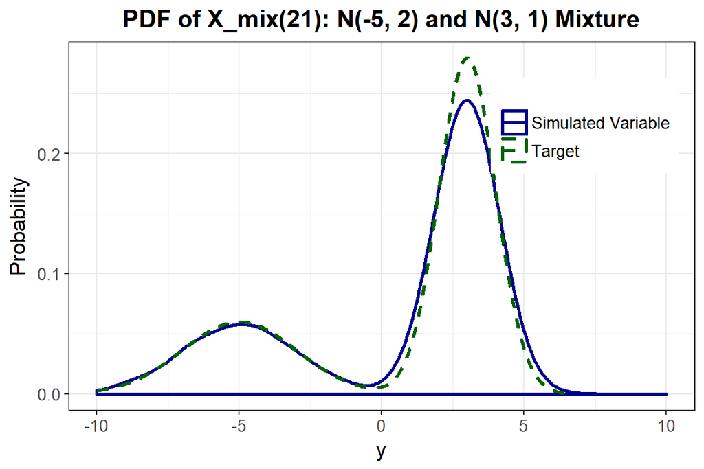

```r
Nplot <- plot_simpdf_theory(sim_y = Sys1$X_all[[1]][, 3], ylower = -10,
  yupper = 10,
  title = "PDF of X_mix(21): N(-5, 2) and N(3, 1) Mixture",
  fx = function(x) mix_pis[[1]][[1]][1] * dnorm(x, mix_mus[[1]][[1]][1],
    mix_sigmas[[1]][[1]][1]) + mix_pis[[1]][[1]][2] *
    dnorm(x, mix_mus[[1]][[1]][2], mix_sigmas[[1]][[1]][2]),
  lower = -Inf, upper = Inf)
Nplot
```

Summary of Ordinal Variable: (for $Y_1$)

```r
knitr::kable(Sum1$ord_sum_x[[1]][1:2, ], digits = 3, row.names = FALSE,
             booktabs = TRUE, caption = "Simulated Distribution of X_ord(1)")
```

Table 9: Simulated Distribution of X_ord(1)

| Outcome | Support | Target | Simulated |
| --- | --- | --- | --- |
| 1 | 0 | 0.333 | 0.334 |
| 1 | 1 | 0.667 | 0.667 |

Summary of Poisson Variable:

```r
knitr::kable(Sum1$pois_sum_x, digits = 3, row.names = FALSE,
             booktabs = TRUE, caption = "Simulated Distribution of X_pois(1)")
```

Table 10: Simulated Distribution of X_pois(1)

| Outcome | X | N | P0 | Exp_P0 | Mean | Exp_Mean | Var | Exp_Var | Median | Min | Max | Skew | Skurtosis |
| --- | --- | --- | --- | --- | --- | --- | --- | --- | --- | --- | --- | --- | --- |
| 1 | 1 | 10000 | 0.101 | 0.1 | 13.495 | 13.5 | 33.785 | 40 | 14 | 0 | 35 | -0.869 | 0.697 |
| 2 | 1 | 10000 | 0.101 | 0.1 | 13.495 | 13.5 | 33.785 | 40 | 14 | 0 | 35 | -0.869 | 0.697 |
| 3 | 1 | 10000 | 0.101 | 0.1 | 13.495 | 13.5 | 33.785 | 40 | 14 | 0 | 35 | -0.869 | 0.697 |

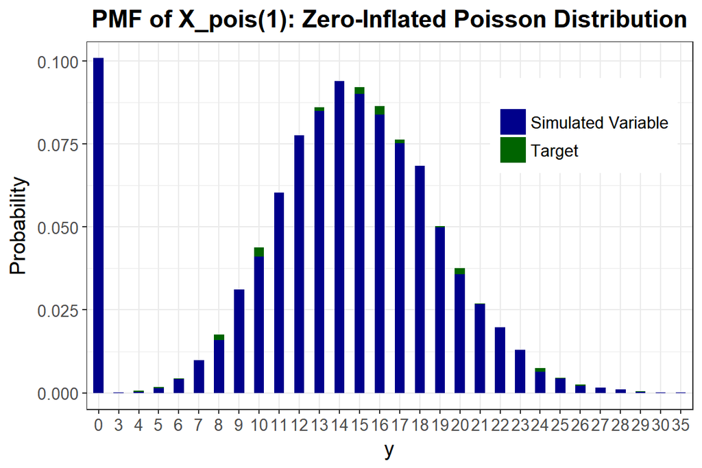

```r
Pplot <- plot_simpdf_theory(sim_y = Sys1$X_all[[1]][, 4],
  title = "PMF of X_pois(1): Zero-Inflated Poisson Distribution",
  Dist = "Poisson", params = c(lam[[1]][1], p_zip), cont_var = FALSE)
Pplot
```

Summary of Negative Binomial Variables $X_{nb(11)}, X_{nb(21)},$ and $X_{nb(31)}$:

```r
knitr::kable(Sum1$nb_sum_x, digits = 3, row.names = FALSE,
             booktabs = TRUE, caption = "Simulated Distributions")
```

Table 11: Simulated Distributions

| Outcome | X | N | P0 | Exp_P0 | Prob | Mean | Exp_Mean | Var | Exp_Var | Median | Min | Max | Skew | Skurtosis |
| --- | --- | --- | --- | --- | --- | --- | --- | --- | --- | --- | --- | --- | --- | --- |
| 1 | 1 | 10000 | 0.069 | 0.073 | 0.769 | 3.001 | 3 | 3.903 | 3.9 | 3 | 0 | 14 | 0.808 | 0.770 |
| 2 | 1 | 10000 | 0.034 | 0.035 | 0.714 | 4.003 | 4 | 5.654 | 5.6 | 4 | 0 | 19 | 0.839 | 1.182 |
| 3 | 1 | 10000 | 0.017 | 0.017 | 0.667 | 5.004 | 5 | 7.452 | 7.5 | 5 | 0 | 20 | 0.727 | 0.698 |

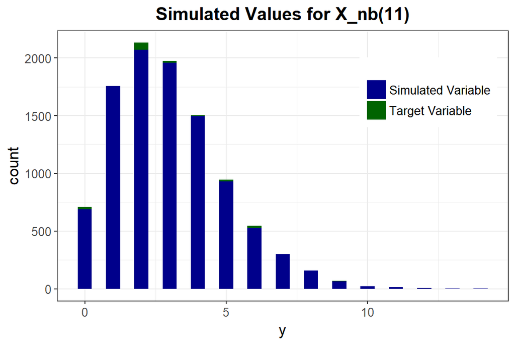

```r
NBplot <- plot_simtheory(sim_y = Sys1$X_all[[1]][, 5], binwidth = 0.5,
  title = "Simulated Values for X_nb(11)", Dist = "Negative_Binomial",
  params = c(size[[1]][1], mu[[1]][1], p_zinb), cont_var = FALSE)
NBplot
```

Maximum Correlation Errors for X Variables by Outcome:

```r
maxerr <- do.call(rbind, Sum1$maxerr)
rownames(maxerr) <- colnames(maxerr) <- paste("Y", 1:M, sep = "")
knitr::kable(as.data.frame(maxerr), digits = 5, booktabs = TRUE,
  caption = "Maximum Correlation Errors for X Variables")
```

Table 12: Maximum Correlation Errors for X Variables

|  | Y1 | Y2 | Y3 |
| --- | --- | --- | --- |
| Y1 | 0.00709 | 0.00804 | 0.00657 |
| Y2 | 0.00804 | 0.00804 | 0.00804 |
| Y3 | 0.00657 | 0.00804 | 0.00657 |

### Linear model

A linear model will be fit to the data using `glm` in order to see if the slope coefficients can be recovered (R Core Team 2017). First, the data is reshaped into long format using `reshape2::melt` (Wickham 2007). Note that since $X_{ord(1)}$ and $X_{pois(1)}$ are the same for each outcome, they will be used as factors (`id.vars`) and are only needed once.

```r
data1 <- as.data.frame(cbind(factor(1:n), Sys1$Y, Sys1$X_all[[1]][, 1:5],
  Sys1$X_all[[2]][, c(2, 3, 5)], Sys1$X_all[[3]][, c(2, 3, 5)]))
colnames(data1)[1] <- "Subject"
data1.a <- melt(data1[, c("Subject", "ord1_1", "pois1_1", "Y1", "Y2", "Y3")],
  id.vars = c("Subject", "ord1_1", "pois1_1"),
  measure.vars = c("Y1", "Y2", "Y3"), variable.name = "Time", value.name = "Y")
data1.b <- melt(data1[, c("Subject", "cont1_1", "cont2_1", "cont3_1")],
  id.vars = c("Subject"), variable.name = "Time", value.name = "cont1")
data1.c <- melt(data1[, c("Subject", "mix1_1", "mix2_1", "mix3_1")],
  id.vars = c("Subject"), variable.name = "Time", value.name = "mix1")
data1.d <- melt(data1[, c("Subject", "nb1_1", "nb2_1", "nb3_1")],
  id.vars = c("Subject"), variable.name = "Time", value.name = "nb1")
data1.a$Time <- data1.b$Time <- data1.c$Time <- data1.d$Time <-
  c(rep(1, n), rep(2, n), rep(3, n))
data1 <- merge(merge(merge(data1.a, data1.b, by = c("Subject", "Time")),
  data1.c, by = c("Subject", "Time")), data1.d, by = c("Subject", "Time"))
```

Errors $E_1, E_2,$ and $E_3$ modeled as having Normal distributions:

```r
fm1 <- glm(Y ~ ord1_1 + cont1 + mix1 + pois1_1 + nb1 + ord1_1:pois1_1 +
  ord1_1:cont1 + pois1_1:cont1 + ord1_1:pois1_1:cont1 +
  ord1_1:mix1 + pois1_1:mix1 + ord1_1:pois1_1:mix1 +
  ord1_1:nb1 + pois1_1:nb1 + ord1_1:pois1_1:nb1 +
  Time + ord1_1:Time + pois1_1:Time, data = data1)
summary(fm1)
```

```
##
## Call:
## glm(formula = Y ~ ord1_1 + cont1 + mix1 + pois1_1 + nb1 + ord1_1:pois1_1 +
##     ord1_1:cont1 + pois1_1:cont1 + ord1_1:pois1_1:cont1 + ord1_1:mix1 +
##     pois1_1:mix1 + ord1_1:pois1_1:mix1 + ord1_1:nb1 + pois1_1:nb1 +
##     ord1_1:pois1_1:nb1 + Time + ord1_1:Time + pois1_1:Time, data = data1)
##
## Deviance Residuals:
##     Min       1Q   Median       3Q      Max
## -3.2143  -0.4958  -0.0895   0.4241   4.6031
##
## Coefficients:
##                       Estimate Std. Error  t value            Pr(>|t|)
## (Intercept)          0.0727547  0.0343919    2.115              0.0344 *
## ord1_1               0.4579595  0.0286148   16.004 <0.0000000000000002 ***
## cont1                0.7589358  0.0053528  141.784 <0.0000000000000002 ***
## mix1                 1.0023232  0.0031825  314.947 <0.0000000000000002 ***
## pois1_1              1.2429948  0.0026613  467.061 <0.0000000000000002 ***
## nb1                  1.4845177  0.0069904  212.366 <0.0000000000000002 ***
## Time                 0.9751990  0.0197703   49.326 <0.0000000000000002 ***
## ord1_1:pois1_1       0.5039399  0.0016936  297.548 <0.0000000000000002 ***
## ord1_1:cont1         0.4993920  0.0041619  119.993 <0.0000000000000002 ***
## cont1:pois1_1        0.5993862  0.0003974 1508.159 <0.0000000000000002 ***
## ord1_1:mix1          0.8007743  0.0033872  236.415 <0.0000000000000002 ***
## mix1:pois1_1         0.9000054  0.0002551 3527.743 <0.0000000000000002 ***
## ord1_1:nb1           1.1045040  0.0060593  182.284 <0.0000000000000002 ***
## pois1_1:nb1          1.2015590  0.0005210 2306.090 <0.0000000000000002 ***
## ord1_1:Time          0.2575984  0.0107161   24.038 <0.0000000000000002 ***
## pois1_1:Time         0.5015038  0.0014760  339.782 <0.0000000000000002 ***
## ord1_1:cont1:pois1_1 0.6999753  0.0002444 2864.155 <0.0000000000000002 ***
## ord1_1:mix1:pois1_1  0.9999631  0.0002245 4454.503 <0.0000000000000002 ***
## ord1_1:pois1_1:nb1   1.2993227  0.0003873 3355.088 <0.0000000000000002 ***
## ---
## Signif. codes:  0 '***' 0.001 '**' 0.01 '*' 0.05 '.' 0.1 ' ' 1
##
## (Dispersion parameter for gaussian family taken to be 0.4800393)
##
##     Null deviance: 3776265562  on 29999  degrees of freedom
## Residual deviance:      14392  on 29981  degrees of freedom
## AIC: 63141
##
## Number of Fisher Scoring iterations: 2
```

```r
fm1.coef <- fm1$coefficients[c("(Intercept)", "ord1_1", "cont1", "mix1",
  "pois1_1", "nb1", "ord1_1:pois1_1", "Time", "ord1_1:cont1", "cont1:pois1_1",
  "ord1_1:cont1:pois1_1", "ord1_1:mix1", "mix1:pois1_1",
  "ord1_1:mix1:pois1_1", "ord1_1:nb1", "pois1_1:nb1",
  "ord1_1:pois1_1:nb1", "ord1_1:Time", "pois1_1:Time")]
coef <- rbind(c(betas.0, betas[[1]], betas.int[[1]], betas.t,
  betas.subj[[1]], betas.tint[[1]]), fm1.coef)
colnames(coef) <- names(fm1.coef)
rownames(coef) <- c("Simulated", "Estimated")
knitr::kable(as.data.frame(coef[, 1:6]), digits = 3, booktabs = TRUE,
  caption = "Beta Coefficients for Repeated Measures Model 1")
```

Table 13: Beta Coefficients for Repeated Measures Model 1

|  | (Intercept) | ord1_1 | cont1 | mix1 | pois1_1 | nb1 |
| --- | --- | --- | --- | --- | --- | --- |
| Simulated | 0.000 | 0.500 | 0.750 | 1.000 | 1.250 | 1.500 |
| Estimated | 0.073 | 0.458 | 0.759 | 1.002 | 1.243 | 1.485 |

```r
knitr::kable(as.data.frame(coef[, 7:12]), digits = 3, booktabs = TRUE)
```

|  | ord1_1:pois1_1 | Time | ord1_1:cont1 | cont1:pois1_1 | ord1_1:cont1:pois1_1 | ord1_1:mix1 |
| --- | --- | --- | --- | --- | --- | --- |
| Simulated | 0.500 | 1.000 | 0.500 | 0.600 | 0.7 | 0.800 |
| Estimated | 0.504 | 0.975 | 0.499 | 0.599 | 0.7 | 0.801 |

```r
knitr::kable(as.data.frame(coef[, 13:19]), digits = 3, booktabs = TRUE)
```

|  | mix1:pois1_1 | ord1_1:mix1:pois1_1 | ord1_1:nb1 | pois1_1:nb1 | ord1_1:pois1_1:nb1 | ord1_1:Time | pois1_1:Time |
| --- | --- | --- | --- | --- | --- | --- | --- |
| Simulated | 0.9 | 1 | 1.100 | 1.200 | 1.300 | 0.250 | 0.500 |
| Estimated | 0.9 | 1 | 1.105 | 1.202 | 1.299 | 0.258 | 0.502 |

All of the slope coefficients are estimated well.

## Example 2: System from Example 1 with no independent variables for $Y_2$

This example uses the `corrsys2` function which employs **correlation method 2**. It requires the additional parameters `pois_eps` and `nb_eps`, which default to $0.0001$ for each variable.

### Step 1: Set up parameter inputs

```r
seed <- 137
n <- 10000
M <- 3

# Ordinal variable
marginal <- list(list(c(1/3, 2/3)), NULL, list(c(1/3, 2/3)))
support <- list(list(c(0, 1, 2)), NULL, list(c(0, 1, 2)))

# Non-mixture continuous variables
skews <- list(c(Stcum1[3], Error1[3]), Error2[3],
  c(Stcum3[3], Error3[3]))
skurts <- list(c(Stcum1[4], Error1[4]), Error2[4],
  c(Stcum3[4], Error3[4]))
fifths <- list(c(Stcum1[5], Error1[5]), Error2[5],
  c(Stcum3[5], Error3[5]))
sixths <- list(c(Stcum1[6], Error1[6]), Error2[6],
  c(Stcum3[6], Error3[6]))
Six <- list(list(0.08, 0.06), NULL, list(0.36, 0.15))

# Mixture continuous variable
mix_pis <- list(list(c(0.3, 0.7)), NULL, list(c(0.3, 0.7)))
mix_mus <- list(list(c(-5, 3)), NULL, list(c(-5, 3)))
mix_sigmas <- list(list(c(2, 1)), NULL, list(c(2, 1)))
mix_skews <- mix_skurts <- mix_fifths <- mix_sixths <-
  list(list(c(0, 0)), NULL, list(c(0, 0)))
mix_Six <- list()

means <- list(c(Stcum1[1], Nstcum[1], Error1[1]), Error2[1],
  c(Stcum3[1], Nstcum[1], Error3[1]))
vars <- list(c(Stcum1[2]^2, Nstcum[2]^2, Error1[2]^2), Error2[2]^2,
  c(Stcum3[2]^2, Nstcum[2]^2, Error3[2]^2))

# Poisson variable
lam <- list(15, NULL, 15)
p_zip <- 0.10

# Negative Binomial variables
size <- list(10, NULL, 10)
mu <- list(3, NULL, 5)
prob <- list()
p_zinb <- 0

# X_ord(1) and X_pois(1) are the same for Y_1 and Y_3
same.var <- matrix(c(1, 1, 3, 1, 1, 5, 3, 5), 2, 4, byrow = TRUE)

# set up X correlation matrix
corr.x <- list()
corr.x[[1]] <- list(matrix(0.4, 6, 6), NULL, matrix(0.25, 6, 6))
diag(corr.x[[1]][[1]]) <- 1
# set correlations between components of X_mix(11) to 0
corr.x[[1]][[1]][3:4, 3:4] <- diag(2)
# set correlations between time-varying covariates of Y1 and Y3
corr.x[[1]][[3]][2, 2] <- 0.5^2
corr.x[[1]][[3]][3:4, 3:4] <- matrix(0.4^2, 2, 2)
corr.x[[1]][[3]][6, 6] <- 0.3^2
# set correlations for the same variables equal across outcomes
corr.x[[1]][[3]][, c(1, 5)] <- corr.x[[1]][[1]][, c(1, 5)]

corr.x[[3]] <- list(t(corr.x[[1]][[3]]), NULL, matrix(0.3, 6, 6))
diag(corr.x[[3]][[3]]) <- 1
# set correlations between components of X_mix(31) to 0
corr.x[[3]][[3]][3:4, 3:4] <- diag(2)
# set correlations for the same variables equal across outcomes
corr.x[[3]][[3]][c(1, 5), ] <- corr.x[[1]][[3]][c(1, 5), ]
corr.x[[3]][[3]][, c(1, 5)] <- t(corr.x[[3]][[3]][c(1, 5), ])

Time <- 1:M
betas.0 <- 0
betas.t <- 1
betas <- list(seq(0.5, 1.5, 0.25), NULL, seq(0.5, 1.5, 0.25))
# interaction between ordinal and Poisson variable, becomes
# another group-level variable
int.var <- matrix(c(1, 1, 4, 3, 1, 4), 2, 3, byrow = TRUE)
betas.int <- list(0.5, NULL, 0.5)
# continuous non-mixture, continuous mixture, and NB variables are
# subject-level variables
subj.var <- matrix(c(1, 2, 1, 3, 1, 5, 3, 2, 3, 3, 3, 5),
  nrow = 6, ncol = 2, byrow = TRUE)
# there are 3 subject-level variables and 3 group-level variables forming
# 9 group-subject interactions
betas.subj <- list(seq(0.5, 0.5 + (9 - 1) * 0.1, 0.1), NULL,
  seq(0.5, 0.5 + (9 - 1) * 0.1, 0.1))
# only ordinal and Poisson variable interact with time (excluding the
# ordinal-Poisson interaction variable)
tint.var <- matrix(c(1, 1, 1, 4, 3, 1, 3, 4), 4, 2, byrow = TRUE)
betas.tint <- list(c(0.25, 0.5), NULL, c(0.25, 0.5))
```

### Step 2: Check parameter inputs

```r
checkpar(M, method, error_type, means, vars, skews, skurts, fifths, sixths,
  Six, mix_pis, mix_mus, mix_sigmas, mix_skews, mix_skurts, mix_fifths,
  mix_sixths, mix_Six, marginal, support, lam, p_zip, pois_eps = list(),
  size, prob, mu, p_zinb, nb_eps = list(), corr.x, corr.yx = list(), corr.e,
  same.var, subj.var, int.var, tint.var, betas.0, betas, betas.subj, betas.int,
  betas.t, betas.tint, quiet = TRUE)
```

```
## [1] TRUE
```

### Step 3: Generate system

```r
Sys2 <- corrsys2(n, M, Time, method, error_type, means, vars,
  skews, skurts, fifths, sixths, Six, mix_pis, mix_mus, mix_sigmas, mix_skews,
  mix_skurts, mix_fifths, mix_sixths, mix_Six, marginal, support, lam, p_zip,
  pois_eps = list(), size, prob, mu, p_zinb, nb_eps = list(), corr.x, corr.e,
  same.var, subj.var, int.var, tint.var, betas.0, betas, betas.subj, betas.int,
  betas.t, betas.tint, seed = seed, use.nearPD = FALSE, quiet = TRUE)
```

```
## Total Simulation time: 0.227 minutes
```

### Step 4: Describe results

```r
Sum2 <- summary_sys(Sys2$Y, Sys2$E, E_mix = NULL, Sys2$X, Sys2$X_all, M,
  method, means, vars, skews, skurts, fifths, sixths, mix_pis, mix_mus,
  mix_sigmas, mix_skews, mix_skurts, mix_fifths, mix_sixths, marginal,
  support, lam, p_zip, size, prob, mu, p_zinb, corr.x, corr.e)
names(Sum2)
```

```
##  [1] "cont_sum_y"   "rho.y"        "cont_sum_e"   "target_sum_e"
##  [5] "rho.e"        "rho.ye"       "ord_sum_x"    "cont_sum_x"
##  [9] "target_sum_x" "sum_xall"     "mix_sum_x"    "target_mix_x"
## [13] "pois_sum_x"   "nb_sum_x"     "rho.x"        "rho.xall"
## [17] "rho.yx"       "rho.yxall"    "maxerr"
```

```r
knitr::kable(Sum2$cont_sum_y, digits = 3, booktabs = TRUE,
  caption = "Simulated Distributions of Outcomes")
```

Table 14: Simulated Distributions of Outcomes

|  | Outcome | N | Mean | SD | Median | Min | Max | Skew | Skurtosis | Fifth | Sixth |
| --- | --- | --- | --- | --- | --- | --- | --- | --- | --- | --- | --- |
| Y1 | 1 | 10000 | 235.280 | 262.080 | 156.027 | -339.268 | 1924.387 | 1.474 | 2.780 | 5.545 | 8.919 |
| Y2 | 2 | 10000 | 2.782 | 0.627 | 2.675 | 1.298 | 6.262 | 0.905 | 0.905 | 0.674 | -0.150 |
| Y3 | 3 | 10000 | 485.996 | 423.620 | 374.110 | -213.943 | 3284.809 | 1.299 | 1.918 | 2.365 | -0.580 |

```r
knitr::kable(Sum2$target_sum_e, digits = 3, booktabs = TRUE,
  caption = "Target Distributions of Error Terms")
```

Table 15: Target Distributions of Error Terms

|  | Outcome | Mean | SD | Skew | Skurtosis | Fifth | Sixth |
| --- | --- | --- | --- | --- | --- | --- | --- |
| E1 | 1 | 0.564 | 0.826 | 0.137 | 0.062 | -0.002 | -0.060 |
| E2 | 2 | 0.782 | 0.623 | 0.851 | 0.705 | -0.043 | -2.326 |
| E3 | 3 | 0.797 | 0.604 | 0.989 | 0.862 | -0.055 | -3.140 |

```r
knitr::kable(Sum2$cont_sum_e, digits = 3, booktabs = TRUE,
  caption = "Simulated Distributions of Error Terms")
```

Table 16: Simulated Distributions of Error Terms

|  | Outcome | N | Mean | SD | Median | Min | Max | Skew | Skurtosis | Fifth | Sixth |
| --- | --- | --- | --- | --- | --- | --- | --- | --- | --- | --- | --- |
| E1 | 1 | 10000 | 0.564 | 0.825 | 0.546 | -2.753 | 3.830 | 0.120 | 0.027 | -0.237 | -0.358 |
| E2 | 2 | 10000 | 0.782 | 0.627 | 0.675 | -0.702 | 4.262 | 0.905 | 0.905 | 0.674 | -0.150 |
| E3 | 3 | 10000 | 0.797 | 0.603 | 0.678 | -0.165 | 5.674 | 1.020 | 1.251 | 2.965 | 17.647 |

```r
knitr::kable(Sum2$target_sum_x, digits = 3, booktabs = TRUE,
  caption = "Target Distributions of Continuous Non-Mixture and Components of
  Mixture Variables")
```

Table 17: Target Distributions of Continuous Non-Mixture and Components of Mixture Variables

|  | Outcome | X | Mean | SD | Skew | Skurtosis | Fifth | Sixth |
| --- | --- | --- | --- | --- | --- | --- | --- | --- |
| cont1_1 | 1 | 1 | 1.33 | 0.693 | 0.618 | 0.210 | -0.365 | -0.879 |
| cont1_2 | 1 | 2 | -5.00 | 2.000 | 0.000 | 0.000 | 0.000 | 0.000 |
| cont1_3 | 1 | 3 | 3.00 | 1.000 | 0.000 | 0.000 | 0.000 | 0.000 |
| cont3_1 | 3 | 1 | 9.09 | 3.658 | 0.210 | -0.185 | -0.024 | 0.416 |
| cont3_2 | 3 | 2 | -5.00 | 2.000 | 0.000 | 0.000 | 0.000 | 0.000 |
| cont3_3 | 3 | 3 | 3.00 | 1.000 | 0.000 | 0.000 | 0.000 | 0.000 |

```r
knitr::kable(Sum2$cont_sum_x, digits = 3, booktabs = TRUE,
  caption = "Simulated Distributions of Continuous Non-Mixture and Components
  of Mixture Variables")
```

Table 18: Simulated Distributions of Continuous Non-Mixture and Components of Mixture Variables

|  | Outcome | X | N | Mean | SD | Median | Min | Max | Skew | Skurtosis | Fifth | Sixth |
| --- | --- | --- | --- | --- | --- | --- | --- | --- | --- | --- | --- | --- |
| cont1_1 | 1 | 1 | 10000 | 1.330 | 0.692 | 1.252 | 0.027 | 4.233 | 0.616 | 0.164 | -0.714 | -2.218 |
| cont1_2 | 1 | 2 | 10000 | -5.000 | 2.000 | -4.984 | -12.661 | 3.968 | 0.008 | -0.033 | 0.077 | 0.233 |
| cont1_3 | 1 | 3 | 10000 | 3.000 | 1.000 | 3.001 | -1.087 | 6.647 | -0.017 | 0.041 | -0.125 | -0.094 |
| cont3_1 | 3 | 1 | 10000 | 9.089 | 3.660 | 9.012 | -0.245 | 24.184 | 0.205 | -0.195 | -0.008 | 0.471 |
| cont3_2 | 3 | 2 | 10000 | -5.000 | 2.000 | -5.011 | -12.762 | 2.251 | 0.008 | -0.013 | -0.051 | -0.158 |
| cont3_3 | 3 | 3 | 10000 | 3.000 | 1.000 | 3.008 | -1.150 | 6.927 | 0.001 | 0.053 | -0.008 | -0.163 |

```r
knitr::kable(Sum2$target_mix_x, digits = 3, booktabs = TRUE,
  caption = "Target Distributions of Continuous Mixture Variables")
```

Table 19: Target Distributions of Continuous Mixture Variables

|  | Outcome | X | Mean | SD | Skew | Skurtosis | Fifth | Sixth |
| --- | --- | --- | --- | --- | --- | --- | --- | --- |
| mix1_1 | 1 | 1 | 0.6 | 3.917 | -0.967 | -0.515 | 5.351 | -7.024 |
| mix3_1 | 3 | 1 | 0.6 | 3.917 | -0.967 | -0.515 | 5.351 | -7.024 |

```r
knitr::kable(Sum2$mix_sum_x, digits = 3, booktabs = TRUE,
  caption = "Simulated Distributions of Continuous Mixture Variables")
```

Table 20: Simulated Distributions of Continuous Mixture Variables

|  | Outcome | X | N | Mean | SD | Median | Min | Max | Skew | Skurtosis | Fifth | Sixth |
| --- | --- | --- | --- | --- | --- | --- | --- | --- | --- | --- | --- | --- |
| mix1_1 | 1 | 1 | 10000 | 0.6 | 3.916 | 2.441 | -11.613 | 6.645 | -0.969 | -0.527 | 5.423 | -7.101 |
| mix3_1 | 3 | 1 | 10000 | 0.6 | 3.916 | 2.425 | -12.392 | 6.903 | -0.981 | -0.482 | 5.391 | -7.545 |

Summary of Ordinal Variable: (for $Y_1$)

```r
knitr::kable(Sum2$ord_sum_x[[1]][1:2, ], digits = 3, row.names = FALSE,
  booktabs = TRUE, caption = "Simulated Distribution of X_ord(1)")
```

Table 21: Simulated Distribution of X_ord(1)

| Outcome | Support | Target | Simulated |
| --- | --- | --- | --- |
| 1 | 0 | 0.333 | 0.336 |
| 1 | 1 | 0.667 | 0.669 |

Summary of Poisson Variable:

```r
knitr::kable(Sum2$pois_sum_x, digits = 3, row.names = FALSE,
  booktabs = TRUE, caption = "Simulated Distribution of X_pois(1)")
```

Table 22: Simulated Distribution of X_pois(1)

| Outcome | X | N | P0 | Exp_P0 | Mean | Exp_Mean | Var | Exp_Var | Median | Min | Max | Skew | Skurtosis |
| --- | --- | --- | --- | --- | --- | --- | --- | --- | --- | --- | --- | --- | --- |
| 1 | 1 | 10000 | 0.096 | 0.1 | 13.525 | 13.5 | 33.205 | 40 | 14 | 0 | 30 | -0.839 | 0.748 |
| 3 | 1 | 10000 | 0.096 | 0.1 | 13.525 | 13.5 | 33.205 | 40 | 14 | 0 | 30 | -0.839 | 0.748 |

```r
knitr::kable(Sum2$nb_sum_x, digits = 3, row.names = FALSE,
  booktabs = TRUE, caption = "Simulated Distributions")
```

Table 23: Simulated Distributions

| Outcome | X | N | P0 | Exp_P0 | Prob | Mean | Exp_Mean | Var | Exp_Var | Median | Min | Max | Skew | Skurtosis |
| --- | --- | --- | --- | --- | --- | --- | --- | --- | --- | --- | --- | --- | --- | --- |
| 1 | 1 | 10000 | 0.072 | 0.073 | 0.769 | 3.009 | 3 | 3.966 | 3.9 | 3 | 0 | 14 | 0.848 | 0.984 |
| 3 | 1 | 10000 | 0.018 | 0.017 | 0.667 | 5.003 | 5 | 7.601 | 7.5 | 5 | 0 | 21 | 0.797 | 0.984 |

Maximum Correlation Errors for X Variables by Outcome:

```r
maxerr <- rbind(Sum2$maxerr[[1]][-2], Sum2$maxerr[[3]][-2])
rownames(maxerr) <- colnames(maxerr) <- c("Y1", "Y3")
knitr::kable(as.data.frame(maxerr), digits = 5, booktabs = TRUE,
  caption = "Maximum Correlation Errors for X Variables")
```

Table 24: Maximum Correlation Errors for X Variables

|  | Y1 | Y3 |
| --- | --- | --- |
| Y1 | 0.00636 | 0.00614 |
| Y3 | 0.00614 | 0.00614 |

## Example 3: System of 4 equations with random intercept and random slope for time

$$\begin{equation}
\begin{split}
Y_1 &= \beta_0 + \beta_1 * X_{O1} + \beta_2 * X_{C11} +\beta_{\rm{subj1}} * X_{O1} * X_{C11} + \beta_{\rm{tint1}} * X_{O1} * Time_1 + \beta_{\rm{t}} * Time_1 + U_0 + U_1 * Time_1 + E_1 \\
Y_2 &= \beta_0 + \beta_1 * X_{O1} + \beta_2 * X_{C21} +\beta_{\rm{subj1}} * X_{O1} * X_{C21} + \beta_{\rm{tint1}} * X_{O1} * Time_2 + \beta_{\rm{t}} * Time_2 + U_0 + U_1 * Time_2 + E_2 \\
Y_3 &= \beta_0 + \beta_1 * X_{O1} + \beta_2 * X_{C31} +\beta_{\rm{subj1}} * X_{O1} * X_{C31} + \beta_{\rm{tint1}} * X_{O1} * Time_3 + \beta_{\rm{t}} * Time_3 + U_0 + U_1 * Time_3 + E_3 \\
Y_4 &= \beta_0 + \beta_1 * X_{O1} + \beta_2 * X_{C41} +\beta_{\rm{subj1}} * X_{O1} * X_{C41} + \beta_{\rm{tint1}} * X_{O1} * Time_4 + \beta_{\rm{t}} * Time_4 + U_0 + U_1 * Time_4 + E_4
\end{split}
\tag{2}
\end{equation}$$

### Description of Variables

1. Ordinal variable $X_{O1}$, where $\Pr[X_{O1} = 0] = 0.2$, $\Pr[X_{O1} = 1] = 0.35$, and $\Pr[X_{O1} = 2] = 0.45$, is a group-level variable and is static across equations.
2. Continuous non-mixture variable $X_{C1}$ is a subject-level variable with a Logistic(0, 1) distribution, which requires a sixth cumulant correction of 1.75.
3. $X$ terms are correlated at 0.1 within an equation and have an AR(1) structure across equations. The correlations for the static variable are held constant across equations.
4. Random intercept $U_0$ and time slope $U_1$ with Normal(0, 1) distributions. Correlation between random effects is 0.3.
5. The error terms have $t$(10) distributions (mean 0, variance 1) and an AR(1, 0.4) correlation structure.

In this example, the random intercept and time slope have continuous non-mixture distributions for all $Y$. However, the functions `corrsys` and `corrsys2` permit a combination of none, non-mixture, and mixture distributions across the $Y$ (i.e., if `rand.int = c("non_mix", "mix", "none")` then the random intercept for $Y_1$ has a non-mixture, and the random intercept for $Y_2$ has a mixture distribution; there is no random intercept for $Y_3$). In addition, the distributions themselves can vary across outcomes. This is also true for random effects assigned to independent variables as specified in `rand.var`.

### Step 1: Set up parameter inputs

```r
seed <- 1
n <- 10000
M <- 4

# Binary variable
marginal <- lapply(seq_len(M), function(x) list(c(0.2, 0.55)))
support <- lapply(seq_len(M), function(x) list(0:2))

same.var <- 1
subj.var <- matrix(c(1, 2, 2, 2, 3, 2, 4, 2), 4, 2, byrow = TRUE)

# create list of X correlation matrices
corr.x <- list()

rho1 <- 0.1
rho2 <- 0.5
rho3 <- rho2^2
rho4 <- rho2^3
# Y_1
corr.x[[1]] <- list(matrix(rho1, 2, 2), matrix(rho2, 2, 2), matrix(rho3, 2, 2),
  matrix(rho4, 2, 2))
diag(corr.x[[1]][[1]]) <- 1
# set correlations for the same variables equal across outcomes
corr.x[[1]][[2]][, same.var] <- corr.x[[1]][[3]][, same.var] <-
  corr.x[[1]][[4]][, same.var] <- corr.x[[1]][[1]][, same.var]

# Y_2
corr.x[[2]] <- list(t(corr.x[[1]][[2]]), matrix(rho1, 2, 2),
  matrix(rho2, 2, 2), matrix(rho3, 2, 2))
diag(corr.x[[2]][[2]]) <- 1
# set correlations for the same variables equal across outcomes
corr.x[[2]][[2]][same.var, ] <- corr.x[[1]][[2]][same.var, ]
corr.x[[2]][[2]][, same.var] <- corr.x[[2]][[3]][, same.var] <-
  corr.x[[2]][[4]][, same.var] <- t(corr.x[[1]][[2]][same.var, ])
corr.x[[2]][[3]][same.var, ] <- corr.x[[1]][[3]][same.var, ]
corr.x[[2]][[4]][same.var, ] <- corr.x[[1]][[4]][same.var, ]

# Y_3
corr.x[[3]] <- list(t(corr.x[[1]][[3]]), t(corr.x[[2]][[3]]),
  matrix(rho1, 2, 2), matrix(rho2, 2, 2))
diag(corr.x[[3]][[3]]) <- 1
# set correlations for the same variables equal across outcomes
corr.x[[3]][[3]][same.var, ] <- corr.x[[1]][[3]][same.var, ]
corr.x[[3]][[3]][, same.var] <- t(corr.x[[3]][[3]][same.var, ])
corr.x[[3]][[4]][same.var, ] <- corr.x[[1]][[4]][same.var, ]
corr.x[[3]][[4]][, same.var] <- t(corr.x[[1]][[3]][same.var, ])

# Y_4
corr.x[[4]] <- list(t(corr.x[[1]][[4]]), t(corr.x[[2]][[4]]),
  t(corr.x[[3]][[4]]), matrix(rho1, 2, 2))
diag(corr.x[[4]][[4]]) <- 1
# set correlations for the same variables equal across outcomes
corr.x[[4]][[4]][same.var, ] <- corr.x[[1]][[4]][same.var, ]
corr.x[[4]][[4]][, same.var] <- t(corr.x[[4]][[4]][same.var, ])

# create error term correlation matrix
corr.e <- matrix(c(1, 0.4, 0.4^2, 0.4^3,
                   0.4, 1, 0.4, 0.4^2,
                   0.4^2, 0.4, 1, 0.4,
                   0.4^3, 0.4^2, 0.4, 1), M, M, byrow = TRUE)

Log <- calc_theory("Logistic", c(0, 1))
t10 <- calc_theory("t", 10)

# Continuous variables: 1st non-mixture, 2nd error terms
means <- lapply(seq_len(M), function(x) c(Log[1], 0))
vars <- lapply(seq_len(M), function(x) c(Log[2]^2, 1))
skews <- lapply(seq_len(M), function(x) c(Log[3], t10[3]))
skurts <- lapply(seq_len(M), function(x) c(Log[4], t10[4]))
fifths <- lapply(seq_len(M), function(x) c(Log[5], t10[5]))
sixths <- lapply(seq_len(M), function(x) c(Log[6], t10[6]))
Six <- lapply(seq_len(M), function(x) list(1.75, NULL))

## RANDOM EFFECTS
rand.int <- "non_mix" # random intercept
rand.tsl <- "non_mix" # random time slope
rand.var <- NULL # no additional random effects

rmeans <- rskews <- rskurts <- rfifths <- rsixths <- c(0, 0)
rvars <- c(1, 1)
rSix <- list(NULL, NULL)

# append parameters for random effect distributions to parameters for
# continuous fixed effects and error terms
means <- append(means, list(rmeans))
vars <- append(vars, list(rvars))
skews <- append(skews, list(rskews))
skurts <- append(skurts, list(rskurts))
fifths <- append(fifths, list(rfifths))
sixths <- append(sixths, list(rsixths))
Six <- append(Six, list(rSix))

# use a list of length 1 so that betas are the same across Y
betas <- list(c(1, 1))
betas.subj <- list(0.5)
betas.tint <- list(0.75)

# set up correlation matrix for random effects
corr.u <- matrix(c(1, 0.3, 0.3, 1), 2, 2)
```

### Step 2: Check parameter inputs

```r
checkpar(M, "Polynomial", "non_mix", means, vars, skews, skurts, fifths,
  sixths, Six, marginal = marginal, support = support, corr.x = corr.x,
  corr.e = corr.e, same.var = same.var, subj.var = subj.var, betas = betas,
  betas.subj = betas.subj, betas.tint = betas.tint, rand.int = rand.int,
  rand.tsl = rand.tsl, corr.u = corr.u, quiet = TRUE)
```

```
## [1] TRUE
```

### Step 3: Generate system

```r
Sys3 <- corrsys(n, M, Time = NULL, "Polynomial", "non_mix", means, vars,
  skews, skurts, fifths, sixths, Six, marginal = marginal, support = support,
  corr.x = corr.x, corr.e = corr.e, same.var = same.var, subj.var = subj.var,
  betas = betas, betas.subj = betas.subj, betas.tint = betas.tint,
  rand.int = rand.int, rand.tsl = rand.tsl, corr.u = corr.u, seed = seed,
  use.nearPD = FALSE, quiet = TRUE)
```

```
## Total Simulation time: 0.005 minutes
```

### Step 4: Describe results

```r
Sum3 <- summary_sys(Sys3$Y, Sys3$E, E_mix = NULL, Sys3$X,
  Sys3$X_all, M, "Polynomial", means, vars, skews, skurts, fifths,
  sixths, marginal = marginal, support = support, corr.x = corr.x,
  corr.e = corr.e, U = Sys3$U, U_all = Sys3$U_all, rand.int = rand.int,
  rand.tsl = rand.tsl, corr.u = corr.u, rmeans2 = Sys3$rmeans2,
  rvars2 = Sys3$rvars2)
names(Sum3)
```

```
##  [1] "cont_sum_y"   "rho.y"        "cont_sum_e"   "target_sum_e"
##  [5] "rho.e"        "rho.ye"       "ord_sum_x"    "cont_sum_x"
##  [9] "target_sum_x" "sum_xall"     "rho.x"        "rho.xall"
## [13] "rho.yx"       "rho.yxall"    "maxerr"       "target_sum_u"
## [17] "cont_sum_u"   "sum_uall"     "rho.u"        "maxerr_u"
```

```r
knitr::kable(Sum3$cont_sum_y, digits = 3, booktabs = TRUE,
  caption = "Simulated Distributions of Outcomes")
```

Table 25: Simulated Distributions of Outcomes

|  | Outcome | N | Mean | SD | Median | Min | Max | Skew | Skurtosis | Fifth | Sixth |
| --- | --- | --- | --- | --- | --- | --- | --- | --- | --- | --- | --- |
| Y1 | 1 | 10000 | 3.269 | 3.926 | 3.047 | -14.527 | 25.868 | 0.374 | 0.829 | 1.476 | 5.402 |
| Y2 | 2 | 10000 | 5.475 | 4.969 | 5.266 | -10.926 | 29.478 | 0.254 | -0.026 | -0.052 | 0.751 |
| Y3 | 3 | 10000 | 7.238 | 5.585 | 7.056 | -13.822 | 31.864 | 0.151 | -0.029 | 0.003 | 0.585 |
| Y4 | 4 | 10000 | 9.099 | 6.403 | 8.950 | -12.072 | 38.790 | 0.132 | 0.027 | 0.177 | 0.609 |

```r
knitr::kable(Sum3$target_sum_u, digits = 3, booktabs = TRUE,
  caption = "Target Distributions of Random Effects")
```

Table 26: Target Distributions of Random Effects

|  | Outcome | U | Mean | SD | Skew | Skurtosis | Fifth | Sixth |
| --- | --- | --- | --- | --- | --- | --- | --- | --- |
| cont1_1 | 1 | 1 | 0 | 1 | 0 | 0 | 0 | 0 |
| cont1_2 | 1 | 2 | 0 | 1 | 0 | 0 | 0 | 0 |

```r
knitr::kable(Sum3$sum_uall, digits = 3, booktabs = TRUE,
  caption = "Simulated Distributions of Random Effects")
```

Table 27: Simulated Distributions of Random Effects

|  | Outcome | U | N | Mean | SD | Median | Min | Max | Skew | Skurtosis | Fifth | Sixth |
| --- | --- | --- | --- | --- | --- | --- | --- | --- | --- | --- | --- | --- |
| U_int | 1 | 1 | 10000 | 0 | 1 | -0.004 | -3.834 | 3.564 | -0.016 | 0.040 | -0.096 | -0.343 |
| U_T1 | 1 | 2 | 10000 | 0 | 1 | 0.014 | -3.415 | 3.933 | -0.003 | -0.044 | 0.239 | -0.171 |

Maximum Correlation Error for Random Effects:

```r
Sum3$maxerr_u
```

```
## [1] 0
```

### Linear mixed model

A linear mixed model will be fit to the data using `lme` from package **nlme** in order to see if the random effects are estimated according to the simulation parameters (Pinheiro et al. 2017). The data is again reshaped into long format using `reshape2::melt`.

```r
data3 <- as.data.frame(cbind(factor(1:n), Sys3$Y,
  Sys3$X_all[[1]][, c(1:2, 5)], Sys3$X_all[[2]][, c(2, 5)],
  Sys3$X_all[[3]][, c(2, 5)], Sys3$X_all[[4]][, c(2, 5)]))
colnames(data3)[1] <- "Subject"
data3.a <- melt(data3[, c("Subject", "ord1_1", "Y1", "Y2", "Y3", "Y4")],
  id.vars = c("Subject", "ord1_1"),
  measure.vars = c("Y1", "Y2", "Y3", "Y4"), variable.name = "Time",
  value.name = "Y")
data3.b <- melt(data3[, c("Subject", "cont1_1", "cont2_1", "cont3_1",
                          "cont4_1")],
  id.vars = c("Subject"), variable.name = "Time", value.name = "cont1")
data3.a$Time <- data3.b$Time <- c(rep(1, n), rep(2, n), rep(3, n), rep(4, n))
data3 <- merge(data3.a, data3.b, by = c("Subject", "Time"))
```

Errors modeled as having Gaussian distributions with an AR(1) correlation structure:

```r
fm3 <- lme(Y ~ ord1_1 * Time + ord1_1 * cont1,
  random = ~ Time | Subject, correlation = corAR1(), data = data3)
sum_fm3 <- summary(fm3)
```

Now, compare betas used in simulation to those returned by `lme`:

```r
fm3.coef <- as.data.frame(sum_fm3$tTable[c("(Intercept)",
  "ord1_1", "cont1", "Time", "ord1_1:cont1", "ord1_1:Time"), ])
coef <- cbind(c(betas.0, betas[[1]], betas.t, betas.subj[[1]],
  betas.tint[[1]]), fm3.coef)
colnames(coef)[1] <- "Simulated"
knitr::kable(as.data.frame(coef), digits = 3, booktabs = TRUE,
  caption = "Beta Coefficients for Repeated Measures Model 2")
```

Table 28: Beta Coefficients for Repeated Measures Model 2

|  | Simulated | Value | Std.Error | DF | t-value | p-value |
| --- | --- | --- | --- | --- | --- | --- |
| (Intercept) | 0.00 | -0.003 | 0.032 | 29996 | -0.108 | 0.914 |
| ord1_1 | 1.00 | 1.001 | 0.022 | 9998 | 46.435 | 0.000 |
| cont1 | 1.00 | 0.997 | 0.007 | 29996 | 151.820 | 0.000 |
| Time | 1.00 | 1.012 | 0.021 | 29996 | 48.222 | 0.000 |
| ord1_1:cont1 | 0.50 | 0.502 | 0.004 | 29996 | 111.984 | 0.000 |
| ord1_1:Time | 0.75 | 0.741 | 0.014 | 29996 | 51.844 | 0.000 |

Estimated standard deviation and AR(1) parameter for error terms:

```r
sum_fm3$sigma
```

```
## [1] 1.00218
```

```r
coef(fm3$modelStruct$corStruct, unconstrained = FALSE)
```

```
##       Phi
## 0.4010826
```

Summary of estimated random effects:

```r
varcor <- VarCorr(fm3)
fm3.ranef <- data.frame(Cor = as.numeric(varcor[2, 3]),
  SD_int = as.numeric(varcor[1, 2]), SD_Tsl = as.numeric(varcor[2, 2]))
knitr::kable(fm3.ranef, digits = 3, booktabs = TRUE)
```

| Cor | SD_int | SD_Tsl |
| --- | --- | --- |
| 0.309 | 0.991 | 0.999 |

# References

Bates, Douglas, and Martin Maechler. 2017. *Matrix: Sparse and Dense Matrix Classes and Methods*. https://CRAN.R-project.org/package=Matrix.

Bates, Douglas, Martin Mächler, Ben Bolker, and Steve Walker. 2015. “Fitting Linear Mixed-Effects Models Using lme4.” *Journal of Statistical Software* 67 (1): 1–48. https://doi.org/10.18637/jss.v067.i01.

Bates, Douglas, Martin Mächler, Ben Bolker, and Steve Walker. 2015. “Fitting Linear Mixed-Effects Models Using Lme4.” *Journal of Statistical Software, Articles* 67 (1): 1–48. https://doi.org/10.18637/jss.v067.i01.

Fialkowski, A C. 2017. *SimMultiCorrData: Simulation of Correlated Data with Multiple Variable Types*. https://CRAN.R-project.org/package=SimMultiCorrData.

———. 2018. *SimCorrMix: Simulation of Correlated Data with Multiple Variable Types Including Continuous and Count Mixture Distributions*. https://CRAN.R-project.org/package=SimCorrMix.

Higham, N. 2002. “Computing the Nearest Correlation Matrix - a Problem from Finance.” *IMA Journal of Numerical Analysis* 22 (3): 329–43. https://doi.org/10.1093/imanum/22.3.329.

Kuznetsova, Alexandra, Per B. Brockhoff, and Rune H. B. Christensen. 2017. “lmerTest Package: Tests in Linear Mixed Effects Models.” *Journal of Statistical Software* 82 (13): 1–26. https://doi.org/10.18637/jss.v082.i13.

Laird, NM, and JH Ware. 1982. “Random-Effects Models for Longitudinal Data.” *Biometrics* 38: 963–74.

Lindstrom, MJ, and DM Bates. 1990. “Nonlinear Mixed Effects Models for Repeated Measures Data.” *Biometrics* 46: 673–87.

Maree, S. 2012. “Correcting Non Positive Definite Correlation Matrices.” BSc Thesis Applied Mathematics, Delft University of Technology. http://resolver.tudelft.nl/uuid:2175c274-ab03-4fd5-85a9-228fe421cdbf.

Pinheiro, Jose, Douglas Bates, Saikat DebRoy, Deepayan Sarkar, and R Core Team. 2017. *nlme: Linear and Nonlinear Mixed Effects Models*. https://CRAN.R-project.org/package=nlme.

R Core Team. 2017. *R: A Language and Environment for Statistical Computing*. Vienna, Austria: R Foundation for Statistical Computing. https://www.R-project.org/.

Wickham, H. 2007. “Reshaping Data with the reshape Package.” *Journal of Statistical Software* 21 (12): 1–20. http://www.jstatsoft.org/v21/i12/.

Yin, JF, and Y Zhang. 2013. “Alternative Gradient Algorithms for Computing the Nearest Correlation Matrix.” *Applied Mathematics and Computation* 219 (14): 7591–9. https://doi.org/10.1016/j.amc.2013.01.045.

Zhang, Y, and JF Yin. Year not provided. “Modified Alternative Gradients Algorithm for Computing the Nearest Correlation Matrix.” Internal paper. Shanghai: Tongji University.